# Functional Data Analysis - Testing the Mean Function

Gonem Lau

december 03, 2023

# Introduction

This report explores the hypothesis testing of the mean function in functional data analysis. Data are modeled after a Brownian motion process, with various statistical techniques applied to assess the characteristics of the mean function.

# Setup and Initialization

Define constants for the analysis

```r
R_REPLICATIONS <- 200
N_SAMPLES <- 100
K_DESIGN_POINTS <- 20
J_BASES <- 100
L_TIMES <- 250
MC_SAMPLES <- 500
J_TRUNCATED_BASES <- 50
NOISE <- 0.5
set.seed(2023)
```

# Utility and Mathematical Functions

Defining utility functions for generating Brownian motion eigenvalues, eigenfunctions, and mean functions.

```r
# Mean functions
zero_mean_fn <- function(time) {
  0
}
sinusoidal_mean_fn <- function(time, amplitude = 1, frequency = 1, phase = 0) {
  amplitude * sin(2 * pi * frequency * time + phase)
}

# Error function
error_functions <- function(sigma, noise_distribution) {
  switch(noise_distribution,
    "normal" = function(time) rnorm(1, mean = 0, sd = sigma),
    "t-distribution" = function(time) rt(1, df = 8) * sigma
  )
}

# Eigenvalue and eigenfunction calculations for Brownian motion
eigen_value_bm <- function(index) {
  1 / (pi^2 * (index - 0.5)^2)
}
eigen_values_bm <- function(num_bases) {
  sapply(seq_len(num_bases), eigen_value_bm)
}
eigen_function_bm <- function(index) {
  function(time) {
    sqrt(2) * sin(pi * (index - 0.5) * time)
  }
}
eigen_functions_bm <- function(num_bases) {
  lapply(seq_len(num_bases), eigen_function_bm)
}
```

# Data Generation

Simulating design points and generating functional data with noise.

```r
library(MASS)

# Function to generate design points
generate_single_design_points <- function(num_times, design_distribution = "uniform") {
  if (design_distribution == "poisson") {
    sort(runif(rpois(1, lambda = num_times), 0, 1))
  } else {
    sort(runif(num_times, 0, 1))
  }
}

# Function to generate scores based on eigenvalues
score_generator <- function(num_samples, eigen_values) {
  num_bases <- length(eigen_values)
  cov <- diag(eigen_values)
  MASS::mvrnorm(n = num_samples, mu = rep(0, num_bases), Sigma = cov)
}

# Function for observation generation
generate_observations <- function(observation_functions, num_times, design_distribution) {
  lapply(observation_functions, function(f) {
    design_points <- generate_single_design_points(num_times, design_distribution)
    observations <- sapply(design_points, f)
    list(observations = observations, design_points = design_points)
  })
}
```

# Function Estimation

Estimating the functions from our observations using two approaches: linear interpolation and Nadaraya-Watson smoothing.

```r
# Function generator
function_generator_bm <- function(mean_fn, scores, eigen_fns) {
  apply(scores, 1, function(score_row) {
    function(time) {
      specific <- sum(mapply(FUN = function(eigen_fn, score) eigen_fn(time) * score, eigen_fns, score_row))
      common <- mean_fn(time)
      return(common + specific)
    }
  })
}

# Empirical mean function
empirical_mean_function <- function(functions) {
  function(time) {
    values_at_time <- sapply(functions, function(f) f(time))
    mean(values_at_time)
  }
}

# Observation function generator
observation_function_generator <- function(functions, error_fn) {
  lapply(functions, function(f) {
    function(time) {
      function_value <- f(time)
      error <- error_fn(time)
      function_value + error
    }
  })
}

# Estimators for interpolated and smoothed functions
estimate_interpolated_functions <- function(observations_with_design_points) {
  lapply(observations_with_design_points, function(data) {
    approxfun(data$design_points, data$observations, method = "linear", rule = 2)
  })
}

estimate_smoothed_functions <- function(observations_with_design_points, bandwidth, kernel) {
  lapply(observations_with_design_points, function(data) {
    function(time) {
      distances <- (time - data$design_points) / bandwidth
      weights <- kernel(distances)
      sum(weights * data$observations) / sum(weights)
    }
  })
}
```

# Statistical Testing

Performing statistical testing to assess the behavior of the test statistic under the null hypothesis.

```r
# Monte Carlo norm approximation
mc_norm <- function(mc_samples, empirical_mean_fn, mean_fn) {
  sampled_norms <- sapply(mc_samples, function(time) {
    (empirical_mean_fn(time) - mean_fn(time))^2
  })
  mean(sampled_norms)
}

# Test norm calculation
test_norm <- function(num_functions, mc_samples, empirical_mean_fn, mean_fn) {
  num_functions * mc_norm(mc_samples, empirical_mean_fn, mean_fn)
}

# Null hypothesis mean realization
mean_null_realization <- function(eigen_values) {
  random_variables <- rchisq(length(eigen_values), df = 1)
  sum(eigen_values * random_variables)
}

# Monte Carlo quantiles calculation
mc_quantiles <- function(mc_samples, eigen_values, probabilities) {
  simulated_sums <- replicate(mc_samples, mean_null_realization(eigen_values))
  quantile(simulated_sums, probabilities)
}

# Gaussian Nadaraya-Watson kernel
gaussianNW <- function(obs) estimate_smoothed_functions(obs, 0.1, dnorm)
```

# Sampling and Replication Functions

The following functions are used for sampling time points and replicating the test norm across multiple samples. This is crucial for assessing the behavior of our test statistic under various conditions.

```r
# Sampling random times uniformly within a specified range
sample_times <- function(n_samples, min_time, max_time) {
  random_samples <- runif(n_samples, min = min_time, max = max_time)
  sort(random_samples)
}

# Generating a grid of times
grid_times <- function(n_samples, min_time, max_time) {
  seq(min_time, max_time, length.out = n_samples)
}

# Replicating the test norm for each sample
replicate_test_norm <- function(num_points, num_times, time_sampler, num_samples, eigen_values, eigen_functions, function_estimator, mean_fn, error_fn, design_distribution, test_mean_fn = NULL) {
  if (is.null(test_mean_fn)) {
    test_mean_fn <- mean_fn
  }

  scores <- score_generator(num_samples, eigen_values)
  functions <- function_generator_bm(mean_fn, scores, eigen_functions)
  observation_functions <- observation_function_generator(functions, error_fn)

  observations <- generate_observations(observation_functions, num_points, design_distribution)
  estimated_functions <- function_estimator(observations)

  empirical_mean_fn <- empirical_mean_function(estimated_functions)
  sampled_times <- time_sampler(num_times, 0, 1)

  test_norm(num_samples, sampled_times, empirical_mean_fn, test_mean_fn)
}
```

# Analysis Execution and Results

This section focuses on executing the functional data analysis with a variety of scenarios to test the mean function. These scenarios encompass variations in noise levels, design point distributions, and error distributions. Each scenario is simulated using the Brownian motion model with different parameters to explore how these factors affect the results of hypothesis testing on the mean function. The simulations involve linear interpolation and Nadaraya-Watson smoothing to estimate functions from noisy observations. The outcomes provide insights into the impact of these variations on the statistical properties of the test for the mean function.

```r
library(parallel)
run_simulation <- function(k_design_points, noise, design_distribution, mean_function, noise_distribution, num_cores) {
  # Brownian Motion simulation setup
  eigen_values <- eigen_values_bm(J_BASES)
  eigen_functions <- eigen_functions_bm(J_BASES)

  # Calculating theoretical quantiles
  probs_seq <- seq(0, 1, by = 0.01)
  truncated_eigen_values <- eigen_values[seq_len(J_TRUNCATED_BASES)]
  quantiles <- mc_quantiles(MC_SAMPLES, truncated_eigen_values, probs_seq)

  error_function <- error_functions(noise, noise_distribution)

  # Running tests in parallel
  parallel_results <- mclapply(c("zero_linear", "zero_smoothed", "mean_linear", "mean_smoothed"), function(test_type) {
    estimator <- ifelse(grepl("linear", test_type), estimate_interpolated_functions, gaussianNW)
    mean_fn <- ifelse(grepl("zero", test_type), zero_mean_fn, mean_function)

    mclapply(seq_len(R_REPLICATIONS), function(i) replicate_test_norm(k_design_points, L_TIMES, grid_times, N_SAMPLES, eigen_values, eigen_functions, estimator, mean_fn, error_function, design_distribution), mc.cores = num_cores)
  }, mc.cores = num_cores, mc.preschedule = FALSE)

  # Extracting results
  results <- setNames(lapply(parallel_results, function(result) sapply(quantiles, function(q) mean(unlist(result) <= q))), c("zero_linear_results", "zero_smoothed_results", "mean_linear_results", "mean_smoothed_results"))

  return(results)
}
```

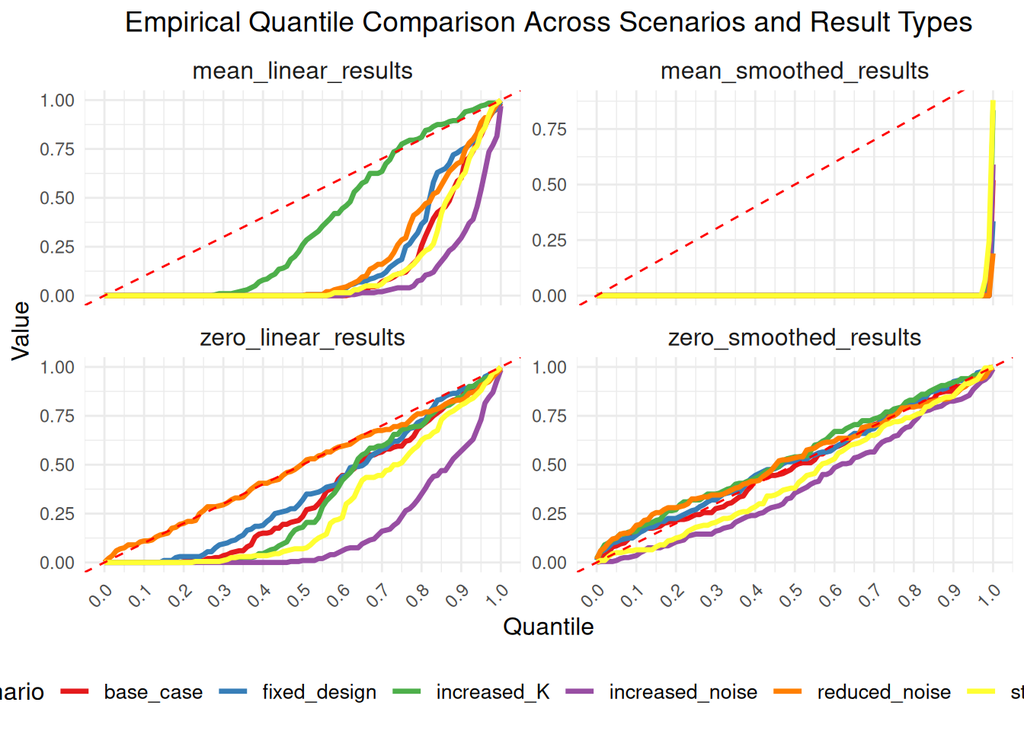

```r
library(ggplot2)
# Parallel processing setup
num_cores <- parallel::detectCores() * 2 / 3
simulations <- list(
  base_case = run_simulation(K_DESIGN_POINTS, NOISE, "poisson", sinusoidal_mean_fn, "normal", num_cores),
  increased_K = run_simulation(100, NOISE, "poisson", sinusoidal_mean_fn, "normal", num_cores),
  reduced_noise = run_simulation(K_DESIGN_POINTS, 0.1, "poisson", sinusoidal_mean_fn, "normal", num_cores),
  increased_noise = run_simulation(K_DESIGN_POINTS, 1, "poisson", sinusoidal_mean_fn, "normal", num_cores),
  fixed_design = run_simulation(K_DESIGN_POINTS, NOISE, "uniform", sinusoidal_mean_fn, "normal", num_cores),
  studentT_noise = run_simulation(K_DESIGN_POINTS, NOISE, "poisson", sinusoidal_mean_fn, "t-distribution", num_cores)
)

# Function to convert simulation results to a data frame for plotting
convert_to_df <- function(simulation_results, scenario_name, result_type) {
  df <- data.frame(
    Quantile = seq(0, 1, by = 0.01),
    Value = simulation_results,
    Scenario = scenario_name,
    ResultType = result_type
  )
  return(df)
}

# Convert each result type for each scenario to a data frame
df_list <- lapply(names(simulations), function(scenario) {
  lapply(names(simulations[[scenario]]), function(result_type) {
    convert_to_df(simulations[[scenario]][[result_type]], scenario, result_type)
  })
})

# Combine all data frames
combined_df <- do.call(rbind, unlist(df_list, recursive = FALSE))

# Plot the empirical quantiles for each scenario and result type, using facets for each result type
ggplot(combined_df, aes(x = Quantile, y = Value, color = Scenario)) +
  geom_line(linewidth = 1.2) +
  geom_abline(slope = 1, intercept = 0, linetype = "dashed", color = "red") + # Adds a reference line
  facet_wrap(~ResultType, scales = "free_y") +
  labs(
    title = "Empirical Quantile Comparison Across Scenarios and Result Types",
    x = "Quantile", y = "Value"
  ) +
  theme_minimal() +
  theme(
    legend.position = "bottom",
    legend.box = "vertical",
    legend.title = element_text(size = 12),
    legend.text = element_text(size = 10),
    plot.title = element_text(hjust = 0.5, size = 14),
    axis.text.x = element_text(angle = 45, hjust = 1),
    axis.title = element_text(size = 12),
    strip.text.x = element_text(size = 12)
  ) +
  scale_x_continuous(breaks = seq(0, 1, by = 0.1)) +
  scale_y_continuous(limits = c(0, NA)) +
  scale_color_brewer(palette = "Set1") +
  guides(col = guide_legend(nrow = 1, override.aes = list(size = 4)))
```

# Conclusion

The analysis of empirical quantiles suggests that the test statistic is not very sensitive to the distribution types of noise. This is evident from the similar results obtained with normal and Student’s t-distribution noise. However, the reliability of the test is affected by noise, especially when non-zero mean functions are present. In such cases, deviations from the expected behavior are more pronounced. The use of smoothing techniques has a dual effect. While it exacerbates deviations for non-zero means, it enhances reliability for null means. Increasing the number of design points results in better alignment with theoretical expectations, emphasizing the importance of rich data. On the other hand, more noise leads to greater dispersion of results, highlighting the vulnerability of the test to data variability. The choice between uniform and Poisson design point distributions has a negligible impact on the outcomes, indicating the robustness of the test to different design point generation methods.